# publication ready viz

bokola

29 October, 2025

# 1 1. Bundestag pie chart

We use following packages for this example

```r
ipk = function(pkg){
  new.pkg = list.pkg[!(list.pkg %in% installed.packages()[, "Package"])]
  # if("practicalgg" %in% list.pkg){
  #   remotes::install_github("wilkelab/practicalgg")
  # }
  if(length(new.pkg)) install.packages(new.pkg, dependencies = T)
  sapply(pkg, require, character.only = T)
}
list.pkg = c("tidyverse", "ggforce", "cowplot", "remotes", "tinter", "ggrepel")
#ggforce for geom_arc_bar()
#cowplot for theme_map()
ipk(list.pkg)
```

```r
fs <- list.files(file.path(here::here(), "data"), full.names = T)
for(i in seq(fs)) load(fs[[i]])
```

We plot a simple pie chart

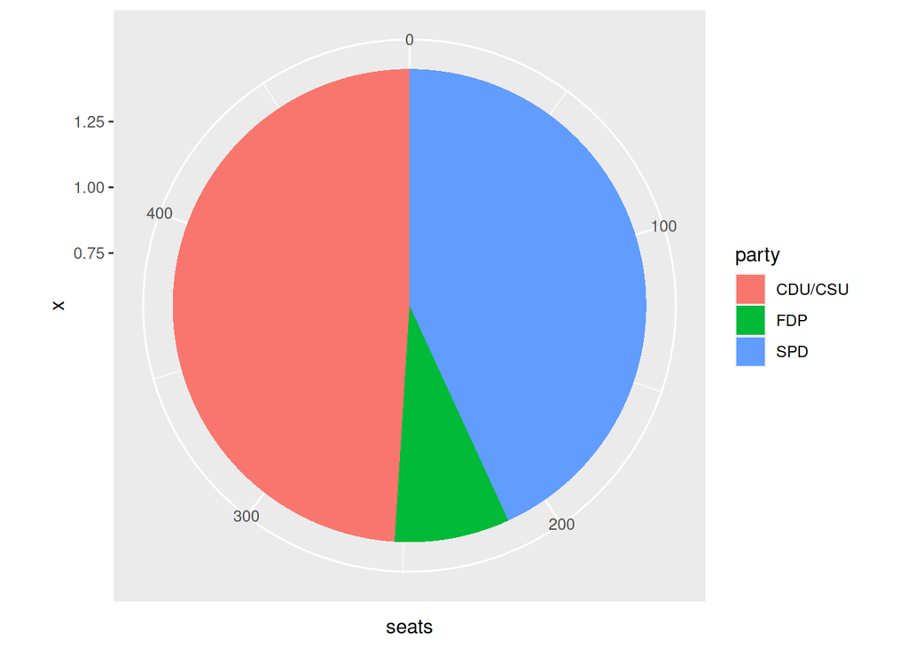

```r
ggplot(bundestag, aes(x = 1, y = seats, fill = party)) +
  geom_col() +
  coord_polar(theta = "y")
```

It is a general preference to plot on a cartesian coordinates, but this would require the use of `geom_arc_bar()` from ggforce. This requires a little more data preparation up front but gives much more predictable results on the back end.

```r
bund_pie = bundestag %>%
  arrange(seats) %>%
  mutate(end_angle = 2*pi*cumsum(seats)/sum(seats), # ending angle for each pie slice
         start_angle = lag(end_angle, default = 0), # starting angle for each pie slice
         mid_angle = 0.5*(start_angle + end_angle), # middle of each pie slice, for the text label
          # horizontal and vertical justifications depend on whether we're to the left/right
          # or top/bottom of the pie
         hjust = ifelse(mid_angle > pi, 1, 0),
         vjust = ifelse(mid_angle < pi/2 | mid_angle > 3*pi/2, 0, 1)
         )
bund_pie
```

```
## # A tibble: 3 × 8
##   party   seats colors  end_angle start_angle mid_angle hjust vjust
##   <chr>   <dbl> <chr>       <dbl>       <dbl>     <dbl> <dbl> <dbl>
## 1 FDP        39 #E7D739     0.494       0         0.247     0     0
## 2 SPD       214 #B6494A     3.20        0.494     1.85      0     1
## 3 CDU/CSU   243 #4E4E4E     6.28        3.20      4.74      1     0
```

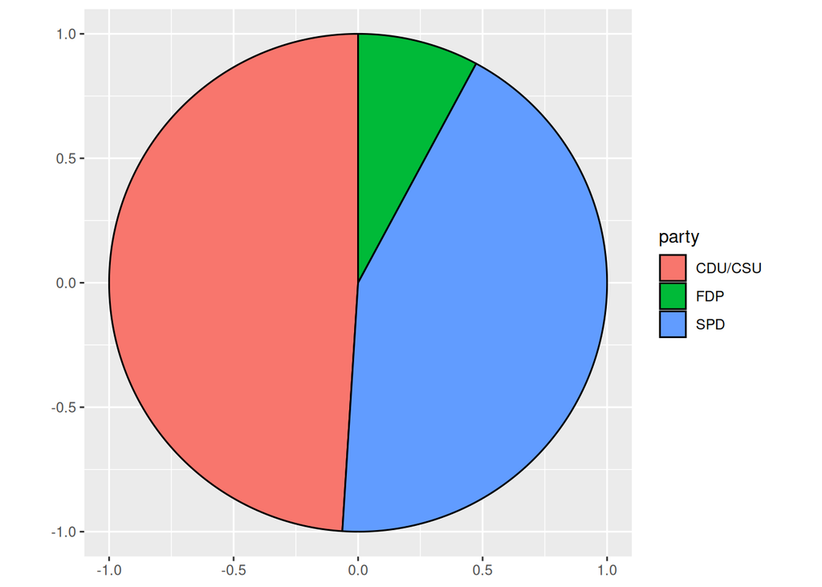

```r
# radius of of the pie and radius for outside and inside labels
rpie = 1
rlabel_out = 1.05*rpie
rlabel_in = 0.6*rpie

ggplot(bund_pie) +
  geom_arc_bar(
    aes(x0 = 0, y0 = 0, r0 = 0, r = rpie,
        start = start_angle, end = end_angle, fill = party)
  ) +
  coord_fixed()
```

Next we add labels representing the number of seats for each party

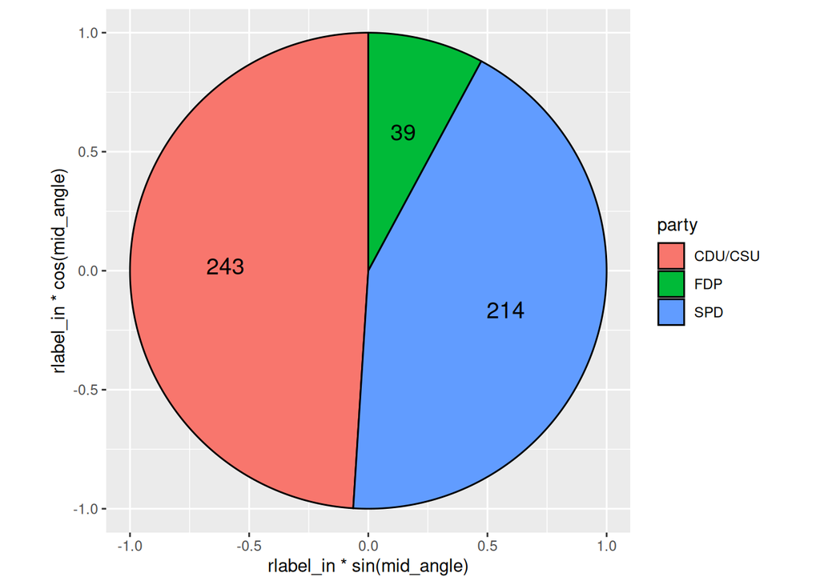

```r
ggplot(bund_pie) +
  geom_arc_bar(
    aes(
      x0 = 0, y0 = 0,
      r0 = 0, r = rpie,
      start = start_angle, end =  end_angle, fill = party
    )
  ) +
  geom_text(
    aes(
      x = rlabel_in * sin(mid_angle),
      y = rlabel_in * cos(mid_angle),
      label = seats
    ),
    size = 14/.pt # use 14 pt font size
  ) +
  coord_fixed()
```

Then provide labels for the parties outside of the pie

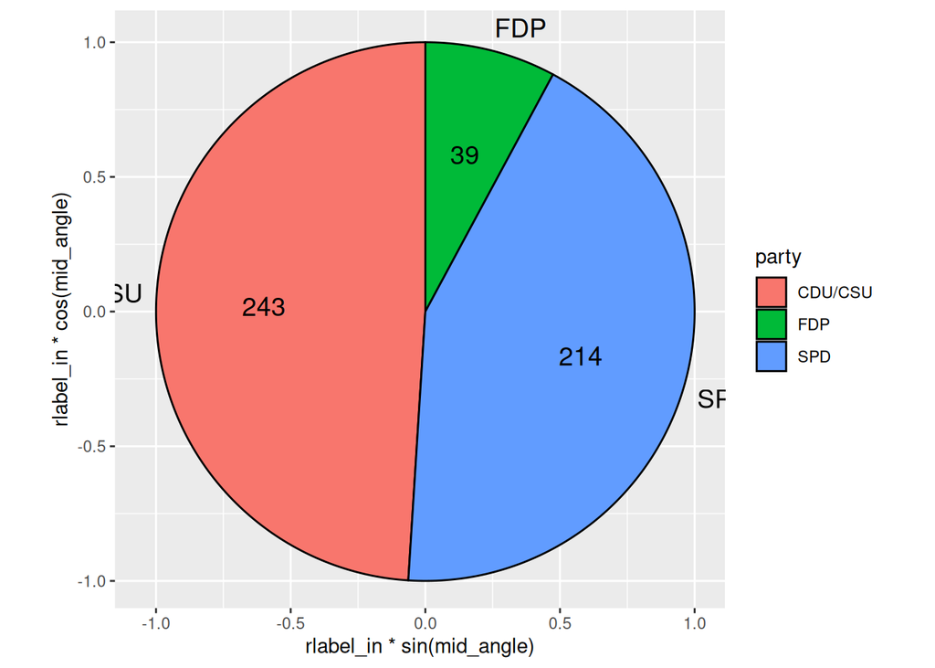

```r
ggplot(bund_pie) +
  geom_arc_bar(
    aes(
      x0 = 0, y0 = 0, r0 = 0, r = rpie,
      start = start_angle, end = end_angle, fill = party
    )
  ) +
  geom_text(
    aes(
      x = rlabel_in * sin(mid_angle),
      y = rlabel_in*cos(mid_angle),
      label = seats
    ),
    size = 14/.pt
  ) +
  geom_text(
    aes(
      x = rlabel_out*sin(mid_angle),
      y = rlabel_out*cos(mid_angle),
      label = party,
      hjust = hjust, vjust = vjust
    ),
    size = 14/.pt
  ) +
  coord_fixed()
```

This plot shows how using cartesian coordinate system is helpful. We can see exactly where elements lie and how we need to extend the limits to fully show all the labels. The CDU/CSU label remains partially obsecured at this point, but this will be fixed later as we remove the legend and axis labels, resulting in slightly more space for the pie chart itself as well as the labels. Next we change the pie colors. The dataset provides appropriate party colors, and we use those directly with `scale_fill_identity()`. Note that this scale eliminates the legend. We don’t need a legend anyways, because we have direct labeled the pie slices.

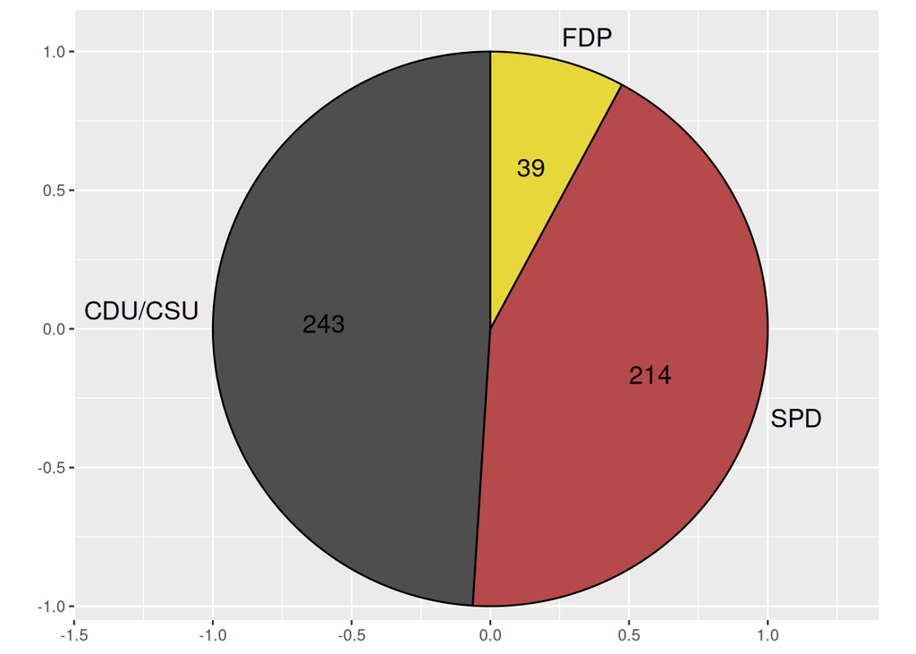

```r
ggplot(bund_pie) +
  geom_arc_bar(
    aes(
      x0 = 0, y0 = 0, r0 = 0, r = rpie,
      start = start_angle, end = end_angle, fill = colors
    )
  ) +
  geom_text(
    aes(
      x = rlabel_in * sin(mid_angle),
      y = rlabel_in * cos(mid_angle),
      label = seats
    ),
    size = 14/.pt
  ) +
  geom_text(
    aes(
      x = rlabel_out * sin(mid_angle),
      y = rlabel_out * cos(mid_angle),
      label = party,
      hjust = hjust, vjust = vjust
    ),
    size = 14/.pt
  ) +
  scale_x_continuous(
    name = NULL,
    limits = c(-1.5, 1.4),
    expand = c(0, 0)
  ) +
  scale_y_continuous(
    name = NULL,
    limits =  c(-1.05, 1.15),
    expand = c(0, 0)
  ) +
  scale_fill_identity() +
  coord_fixed()
```

The black colour for the text labels doesn’t work well on top of the dark fill colours, and the black outline also looks overbearing, so we’ll change those colours to white.

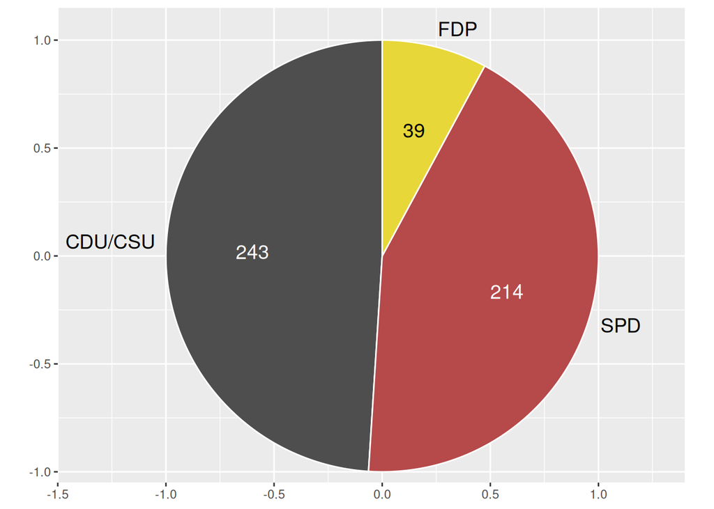

```r
ggplot(bund_pie) +
  geom_arc_bar(
    aes(
      x0 = 0, y0 = 0, r0 = 0, r = rpie,
      start = start_angle, end =  end_angle, fill = colors
    ),
    color = 'white'
  ) +
  geom_text(
    aes(
      x = rlabel_in * sin(mid_angle),
      y = rlabel_in * cos(mid_angle),
      label = seats
    ),
    size = 14/.pt,
    color = c("black", "white", "white")
  ) +
  geom_text(
    aes(
      x = rlabel_out * sin(mid_angle),
      y = rlabel_out * cos(mid_angle),
      label = party,
      hjust = hjust, vjust = vjust
    ),
    size = 14/.pt
  ) +
  scale_x_continuous(
    name = NULL,
    limits = c(-1.5, 1.4),
    expand = c(0, 0)
  ) +
  scale_y_continuous(
    name = NULL,
    limits = c(-1.05, 1.15),
    expand = c(0, 0)
  ) +
  scale_fill_identity() +
  coord_fixed()
```

Finally, we apply a theme that removes the background grid and axes

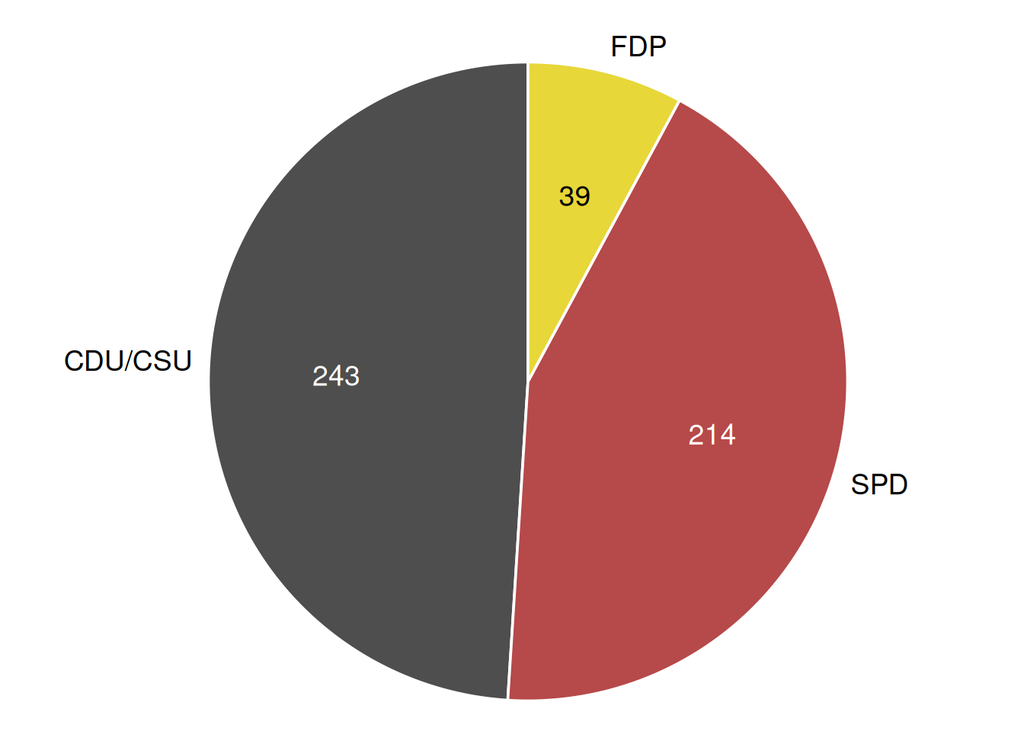

```r
ggplot(bund_pie) +
  geom_arc_bar(
    aes(
      x0 = 0, y0 = 0, r0 = 0, r = rpie,
      start = start_angle, end = end_angle, fill = colors
    ),
    color = "white"
  ) +
  geom_text(
    aes(
      x = rlabel_in * sin(mid_angle),
      y = rlabel_in * cos(mid_angle),
      label = seats
    ),
    size = 14/.pt,
    color = c("black", "white", "white")
  ) +
  geom_text(
    aes(
      x = rlabel_out * sin(mid_angle),
      y = rlabel_out * cos(mid_angle),
      label = party,
      hjust = hjust, vjust = vjust
    ),
    size = 14/.pt
  ) +
  scale_x_continuous(
    name = NULL,
    limits = c(-1.5, 1.4),
    expand = c(0, 0)
  ) +
  scale_y_continuous(
    name = NULL,
    limits = c(-1.05, 1.15),
    expand = c(0, 0)
  ) +
  scale_fill_identity() +
  coord_fixed() +
  theme_map()
```

# 2. Scatter plot with smoothing line

The data is provided as `practicalgg::corruption`. Let’s look at it in a table form and in basic scatter plot form.

```r
corruption <- corruption %>% filter(year == 2015) %>%
  na.omit()
glimpse(corruption)
```

```
## Rows: 163
## Columns: 6
## $ country <chr> "Denmark", "New Zealand", "Finland", "Sweden", "Switzerland", …
## $ region  <chr> "Europe and Central Asia", "Asia Pacific", "Europe and Central…
## $ year    <dbl> 2015, 2015, 2015, 2015, 2015, 2015, 2015, 2015, 2015, 2015, 20…
## $ cpi     <dbl> 91, 91, 90, 89, 86, 88, 85, 84, 83, 81, 85, 81, 79, 79, 77, 75…
## $ iso3c   <chr> "DNK", "NZL", "FIN", "SWE", "CHE", "NOR", "SGP", "NLD", "CAN",…
## $ hdi     <dbl> 0.925, 0.915, 0.895, 0.913, 0.939, 0.949, 0.925, 0.924, 0.920,…
```

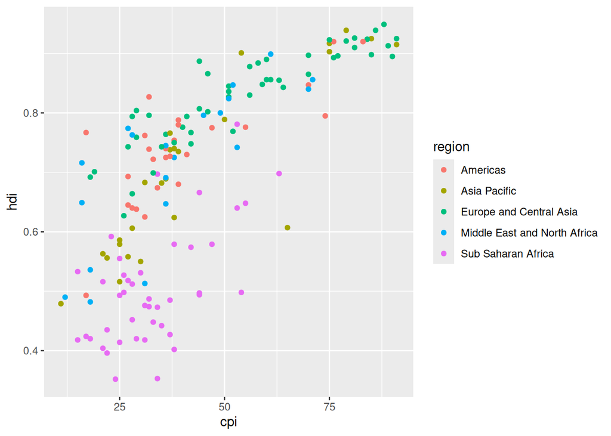

```r
ggplot(corruption, aes(cpi, hdi, color = region)) +
  geom_point()
```

Basic styling: point colors and theme

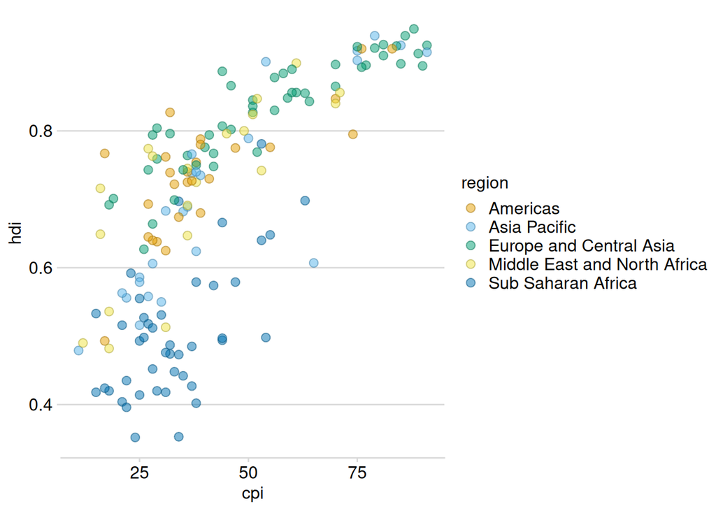

```r
region_cols <- c("#E69F00", "#56B4E9", "#009E73", "#F0E442", "#0072B2", "#999999")
ggplot(corruption, aes(cpi, hdi)) +
  geom_point(
    aes(color = region, fill = region),
    size = 2.5, alpha = 0.5, shape = 21
  ) +
  scale_color_manual(
    values = darken(region_cols, 0.3)
  ) +
  scale_fill_manual(
    values = region_cols
  ) +
  theme_minimal_hgrid(12, rel_small = 1) # font size 12 pt throughout
```

Add smoothing line

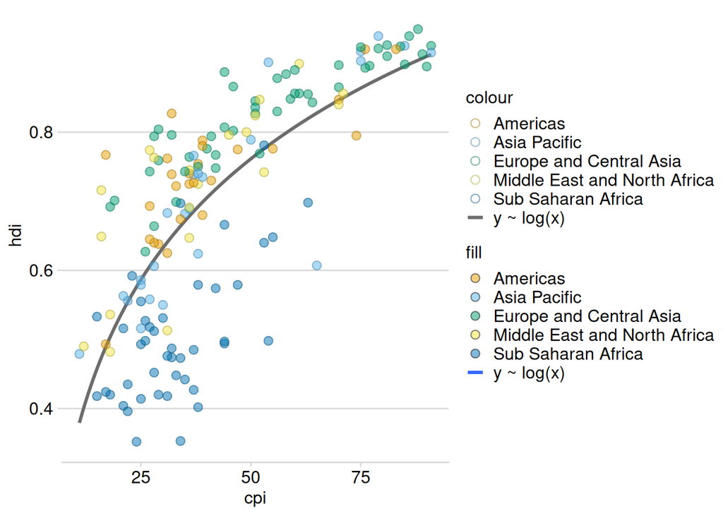

```r
ggplot(corruption, aes(cpi, hdi)) +
  geom_smooth(
    aes(color = "y ~ log(x)", fill = "y ~ log(x)"),
    method = "lm", formula = y ~ log(x), se = FALSE, fullrange = TRUE
  ) +
  geom_point(
    aes(color = region, fill = region),
    size = 2.5, alpha = 0.5, shape = 21
  ) +
  scale_color_manual(
    values = darken(region_cols, 0.3)
  ) +
  scale_fill_manual(
    values = region_cols
  ) +
  theme_minimal_hgrid(12, rel_small = 1)
```

Set the scale name for color and fill scale, to force merging of guides

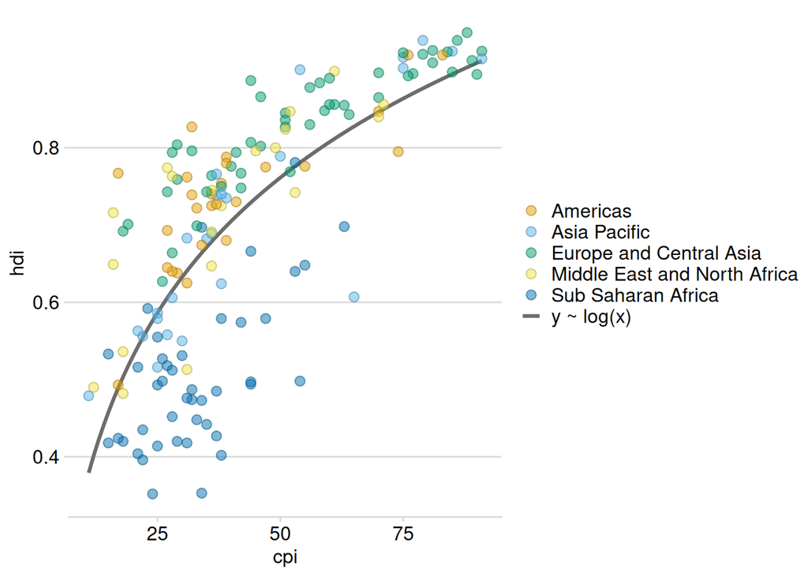

```r
ggplot(corruption, aes(cpi, hdi)) +
  geom_smooth(
    aes(color = "y ~ log(x)", fill = "y ~ log(x)"),
    method = "lm", formula = y ~ log(x), se = FALSE, fullrange = TRUE
  ) +
  geom_point(
    aes(color = region, fill = region),
    size = 2.5, alpha = 0.5, shape = 21
  ) +
  scale_color_manual(
    name = NULL,
    values = darken(region_cols, 0.3)
  ) +
  scale_fill_manual(
    name = NULL,
    values = region_cols
  ) +
  theme_minimal_hgrid(12, rel_small = 1)
```

Override legend aesthetics